# Biostat 212a Homework 2

Due Feb 6, 2024 @ 11:59PM

Author

Wenqing Mao, UID:806332971

Published

February 6, 2024

## 1 ISL Exercise 4.8.1 (10pts)

**Answer:**

$$\begin{align*}
P(X)&=\frac{e^{\beta_{0}+\beta_{1}X}}{1+e^{\beta_{0}+\beta_{1}X}}\quad(4.2)\\
&\Leftrightarrow P(X)(1+e^{\beta_{0}+\beta_{1}X})=e^{\beta_{0}+\beta_{1}X}\\
&\Leftrightarrow P(X)+P(X)e^{\beta_{0}+\beta_{1}X}=e^{\beta_{0}+\beta_{1}X}\\
&\Leftrightarrow P(X)=e^{\beta_{0}+\beta_{1}X}-P(X)e^{\beta_{0}+\beta_{1}X}\\
&\Leftrightarrow P(X)=e^{\beta_{0}+\beta_{1}X}(1-P(X))\\
&\Leftrightarrow \frac{P(X)}{1-P(X)}=e^{\beta_{0}+\beta_{1}X}\quad(4.3)
\end{align*}$$

## 2 ISL Exercise 4.8.6 (10pts)

**Answer:**

**(a)**
$$\begin{align*}
P(X)&=\frac{e^{\beta_{0}+\beta_{1}X_{1}+\beta_{2}X_{2}}}{1+e^{\beta_{0}+\beta_{1}X_{1}+\beta_{2}X_{2}}}\\
&=\frac{e^{-6+0.05X_{1}+X_{2}}}{1+e^{-6+0.05X_{1}+X_{2}}}\\
\end{align*}$$
Plug in $X_{1}=40$ and $X_{2}=3.5$, we can get $P(X)=0.3775$.

**(b)**

Holding $X_{2}=3.5$ fixed, and we aim to get the value of $X_{1}$ that makes $P(X)=0.5$. We can solve the equation
$$0.5=\frac{e^{-6+0.05X_{1}+3.5}}{1+e^{-6+0.05X_{1}+3.5}}$$
and get $X_{1}=50$.

In conclusion, the student in part (a) need to study 50 hours to have a 50 % chance of getting an A.

## 3 ISL Exercise 4.8.9 (10pts)

**Answer:**

**(a)**
$$0.37=\frac{P(X)}{1-P(X)} \Rightarrow P(X)=\frac{0.37}{1+0.37}=0.27$$
**(b)**
$$odd \ ratio=\frac{P(X)}{1-P(X)}=\frac{0.16}{1-0.16}=0.19$$

## 4 ISL Exercise 4.8.13 (a)-(i) (50pts)

**Answer:**

**(a)**

```r
library(ISLR2)
library(tidyverse)

 Weekly <- as_tibble(Weekly) %>%
   print(width = Inf)
```

```
# A tibble: 1,089 × 9
    Year   Lag1   Lag2   Lag3   Lag4   Lag5 Volume  Today Direction
   <dbl>  <dbl>  <dbl>  <dbl>  <dbl>  <dbl>  <dbl>  <dbl> <fct>
 1  1990  0.816  1.57  -3.94  -0.229 -3.48   0.155 -0.27  Down
 2  1990 -0.27   0.816  1.57  -3.94  -0.229  0.149 -2.58  Down
 3  1990 -2.58  -0.27   0.816  1.57  -3.94   0.160  3.51  Up
 4  1990  3.51  -2.58  -0.27   0.816  1.57   0.162  0.712 Up
 5  1990  0.712  3.51  -2.58  -0.27   0.816  0.154  1.18  Up
 6  1990  1.18   0.712  3.51  -2.58  -0.27   0.154 -1.37  Down
 7  1990 -1.37   1.18   0.712  3.51  -2.58   0.152  0.807 Up
 8  1990  0.807 -1.37   1.18   0.712  3.51   0.132  0.041 Up
 9  1990  0.041  0.807 -1.37   1.18   0.712  0.144  1.25  Up
10  1990  1.25   0.041  0.807 -1.37   1.18   0.134 -2.68  Down
# ℹ 1,079 more rows
```

```r
summary(Weekly)
```

```
      Year           Lag1               Lag2               Lag3
 Min.   :1990   Min.   :-18.1950   Min.   :-18.1950   Min.   :-18.1950
 1st Qu.:1995   1st Qu.: -1.1540   1st Qu.: -1.1540   1st Qu.: -1.1580
 Median :2000   Median :  0.2410   Median :  0.2410   Median :  0.2410
 Mean   :2000   Mean   :  0.1506   Mean   :  0.1511   Mean   :  0.1472
 3rd Qu.:2005   3rd Qu.:  1.4050   3rd Qu.:  1.4090   3rd Qu.:  1.4090
 Max.   :2010   Max.   : 12.0260   Max.   : 12.0260   Max.   : 12.0260
      Lag4               Lag5              Volume            Today
 Min.   :-18.1950   Min.   :-18.1950   Min.   :0.08747   Min.   :-18.1950
 1st Qu.: -1.1580   1st Qu.: -1.1660   1st Qu.:0.33202   1st Qu.: -1.1540
 Median :  0.2380   Median :  0.2340   Median :1.00268   Median :  0.2410
 Mean   :  0.1458   Mean   :  0.1399   Mean   :1.57462   Mean   :  0.1499
 3rd Qu.:  1.4090   3rd Qu.:  1.4050   3rd Qu.:2.05373   3rd Qu.:  1.4050
 Max.   : 12.0260   Max.   : 12.0260   Max.   :9.32821   Max.   : 12.0260
 Direction
 Down:484
 Up  :605
```

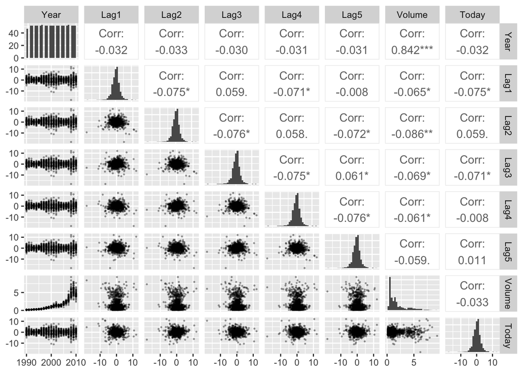

```r
library(GGally)
ggpairs(Weekly[,1:8], lower=list(continuous=wrap("points", alpha=0.3, size=0.3)),
        diag=list(continuous='barDiag')) +
  scale_x_continuous(breaks = scales::pretty_breaks(n = 3)) +
  scale_y_continuous(breaks = scales::pretty_breaks(n = 3))
```

The first column of the plot is the time series trend of the market data. We can see that the returns are not stable and has a lot of fluctuations, and trade volumn is increasing over time. In terms of correlation, lag returns doesn’t correlated with each other, but the volumn is strongly positively correlated with the Year, which means as the year goes by, the market volumn increases. From the histogram, we can see that the volume is right-skewed, and the lag returns are normally distributed.

**(b)**

```r
logit_mod <- glm(
  Direction ~ Lag1 + Lag2 + Lag3 + Lag4 + Lag5 + Volume,
  family = binomial,
  data = Weekly
  )

summary(logit_mod)
```

```
Call:
glm(formula = Direction ~ Lag1 + Lag2 + Lag3 + Lag4 + Lag5 +
    Volume, family = binomial, data = Weekly)

Coefficients:
            Estimate Std. Error z value Pr(>|z|)
(Intercept)  0.26686    0.08593   3.106   0.0019 **
Lag1        -0.04127    0.02641  -1.563   0.1181
Lag2         0.05844    0.02686   2.175   0.0296 *
Lag3        -0.01606    0.02666  -0.602   0.5469
Lag4        -0.02779    0.02646  -1.050   0.2937
Lag5        -0.01447    0.02638  -0.549   0.5833
Volume      -0.02274    0.03690  -0.616   0.5377
---
Signif. codes:  0 '***' 0.001 '**' 0.01 '*' 0.05 '.' 0.1 ' ' 1

(Dispersion parameter for binomial family taken to be 1)

    Null deviance: 1496.2  on 1088  degrees of freedom
Residual deviance: 1486.4  on 1082  degrees of freedom
AIC: 1500.4

Number of Fisher Scoring iterations: 4
```

The p-value of Lag2 is 0.0296 which is less than 0.05, so we can reject the null hypothesis and conclude that Lag2 is statistical significant at 95% confidence level.

**(c)**

```r
# Predicted labels from logistic regression
logit_pred = ifelse(
  predict(logit_mod, Weekly, type = "response") > 0.5,
  "Up",
  "Down"
)

# Confusion matrix
logit_cfm = table(Predicted = logit_pred, Weekly = Weekly$Direction)
logit_cfm
```

```
         Weekly
Predicted Down  Up
     Down   54  48
     Up    430 557
```

The confusion matrix can reflect mistakes of total test error, false positive and false negative. Test error is the proportion of mistakes made by the model. False positive is the observations that are actually down but predicted up, and false negative is the observations that are actually up but predicted down.

```r
# Test Error
1-sum(diag(logit_cfm)) / sum(logit_cfm)
```

```
[1] 0.4389348
```

```r
# FPR
logit_cfm['Up', 'Down'] / sum(logit_cfm[, 'Down'])
```

```
[1] 0.8884298
```

```r
# FNR
logit_cfm['Down', 'Up'] / sum(logit_cfm[, 'Up'])
```

```
[1] 0.07933884
```

**(d)**

```r
# Subset data into training and testing sets
Weekly_train <- Weekly %>%
  filter(Year < 2009)

Weekly_test <- Weekly %>%
  filter(Year >= 2009)

# Fit logistic regression model
logit_mod2 <- glm(
  Direction ~ Lag2,
  family = binomial,
  data = Weekly_train
)
summary(logit_mod2)
```

```
Call:
glm(formula = Direction ~ Lag2, family = binomial, data = Weekly_train)

Coefficients:
            Estimate Std. Error z value Pr(>|z|)
(Intercept)  0.20326    0.06428   3.162  0.00157 **
Lag2         0.05810    0.02870   2.024  0.04298 *
---
Signif. codes:  0 '***' 0.001 '**' 0.01 '*' 0.05 '.' 0.1 ' ' 1

(Dispersion parameter for binomial family taken to be 1)

    Null deviance: 1354.7  on 984  degrees of freedom
Residual deviance: 1350.5  on 983  degrees of freedom
AIC: 1354.5

Number of Fisher Scoring iterations: 4
```

```r
# Predicted labels from logistic regression
logit_pred2 = ifelse(
  predict(logit_mod, Weekly_test, type = "response") > 0.5,
  "Up",
  "Down"
)

# Confusion matrix
logit_cfm2 = table(Logit_Predicted = logit_pred2, Direction = Weekly_test$Direction)
logit_cfm2
```

```
               Direction
Logit_Predicted Down Up
           Down   17 13
           Up     26 48
```

```r
# Accuracy
(logit_cfm2['Up', 'Up'] + logit_cfm2['Down', 'Down']) / sum(logit_cfm2)
```

```
[1] 0.625
```

**(e)**

```r
library(MASS)
# Fit LDA
lda_mod <- lda(
  Direction ~ Lag2,
  data = Weekly_train
  )
lda_mod
```

```
Call:
lda(Direction ~ Lag2, data = Weekly_train)

Prior probabilities of groups:
     Down        Up
0.4477157 0.5522843

Group means:
            Lag2
Down -0.03568254
Up    0.26036581

Coefficients of linear discriminants:
           LD1
Lag2 0.4414162
```

```r
# Predicted labels from LDA
lda_pred = predict(lda_mod, Weekly_test)

# Confusion matrix
lda_cfm = table(LDA_Predicted = lda_pred$class, Direction = Weekly_test$Direction)
lda_cfm
```

```
             Direction
LDA_Predicted Down Up
         Down    9  5
         Up     34 56
```

```r
# Accuracy
(lda_cfm['Up', 'Up'] + lda_cfm['Down', 'Down']) / sum(lda_cfm)
```

```
[1] 0.625
```

**(f)**

```r
# Fit QDA
qda_mod <- qda(
  Direction ~ Lag2,
  data = Weekly_train
  )

qda_mod
```

```
Call:
qda(Direction ~ Lag2, data = Weekly_train)

Prior probabilities of groups:
     Down        Up
0.4477157 0.5522843

Group means:
            Lag2
Down -0.03568254
Up    0.26036581
```

```r
# Predicted probabilities from QDA
qda_pred = predict(qda_mod, Weekly_test)

# Confusion matrix
qda_cfm = table(QDA_Predicted = qda_pred$class, Direction = Weekly_test$Direction)
qda_cfm
```

```
             Direction
QDA_Predicted Down Up
         Down    0  0
         Up     43 61
```

```r
# Accuracy
(qda_cfm['Up', 'Up'] + qda_cfm['Down', 'Down']) / sum(qda_cfm)
```

```
[1] 0.5865385
```

**(g)**

```r
# Fit KNN
library(class)

knn_pred <- knn(
  train = Weekly_train[, c("Lag2")],
  test = Weekly_test[, c("Lag2")],
  cl = Weekly_train$Direction,
  k = 1
  )

# Confusion matrix
(knn_cfm = table(KNN_Predicted = knn_pred, Direction = Weekly_test$Direction))
```

```
             Direction
KNN_Predicted Down Up
         Down   21 30
         Up     22 31
```

```r
# Accuracy
(knn_cfm['Up', 'Up'] + knn_cfm['Down', 'Down']) / sum(knn_cfm)
```

```
[1] 0.5
```

**(h)**

```r
# Fit naive Bayes
library(e1071)

nb_mod <- naiveBayes(
  Direction ~ Lag2,
  data = Weekly_train
  )
nb_mod
```

```
Naive Bayes Classifier for Discrete Predictors

Call:
naiveBayes.default(x = X, y = Y, laplace = laplace)

A-priori probabilities:
Y
     Down        Up
0.4477157 0.5522843

Conditional probabilities:
      Lag2
Y             [,1]     [,2]
  Down -0.03568254 2.199504
  Up    0.26036581 2.317485
```

```r
# Predicted labels from Naive Bayes
nb_pred = predict(nb_mod, Weekly_test)

# Confusion matrix
(nb_cfm = table(NB_Predicted = nb_pred, Direction = Weekly_test$Direction))
```

```
            Direction
NB_Predicted Down Up
        Down    0  0
        Up     43 61
```

```r
# Accuracy
(nb_cfm['Up', 'Up'] + nb_cfm['Down', 'Down']) / sum(nb_cfm)
```

```
[1] 0.5865385
```

**(i)**

```r
library(pROC)

acc_f = function(cfm) {
  (cfm['Up', 'Up'] + cfm['Down', 'Down']) / sum(cfm)
}

fpr_f = function(cfm) {
  cfm['Up', 'Down'] / sum(cfm[, 'Down'])
}

fnr_f = function(cfm) {
  cfm['Down', 'Up'] / sum(cfm[, 'Up'])
}

auc_f = function(pred) {
  y = pred$y
  pred_prob = pred$prob
  roc_object <- roc(y, pred_prob)
  auc_c = auc(roc_object)[1]
  return(auc_c)
}

logit_pred_prob <- predict(logit_mod2, Weekly_test, type = "response")
lda_pred_prob <- lda_pred$posterior[, 2]
qda_pred_prob <- qda_pred$posterior[, 2]
nb_pred_prob <- predict(nb_mod, Weekly_test, type = "raw")[, 2]
knn_mod <- knn(
  train = Weekly_train[, c("Lag2")],
  test = Weekly_test[, c("Lag2")],
  cl = Weekly_train$Direction,
  prob = TRUE,
  k = 1
  )
knn_pred_prob <- 1 - attr(knn_mod, "prob")

row_names = c("Logit", "LDA", "QDA", "NB", "KNN")
acc_v = sapply(list(logit_cfm, lda_cfm, qda_cfm, nb_cfm, knn_cfm), acc_f)
fpr_v = sapply(list(logit_cfm, lda_cfm, qda_cfm, nb_cfm, knn_cfm), fpr_f)
fnr_v = sapply(list(logit_cfm, lda_cfm, qda_cfm, nb_cfm, knn_cfm), fnr_f)
auc_v = sapply(list(data.frame(y = Weekly_test$Direction,
                             prob = logit_pred_prob),
                  data.frame(y = Weekly_test$Direction,
                             prob = lda_pred_prob),
                  data.frame(y = Weekly_test$Direction,
                             prob = qda_pred_prob),
                  data.frame(y = Weekly_test$Direction,
                             prob = nb_pred_prob),
                  data.frame(y = Weekly_test$Direction,
                             prob = knn_pred_prob)),
             auc_f)

tibble(Classifier = row_names,
       ACC = acc_v,
       FPR =  fpr_v,
       FNR =  fnr_v,
       AUC = auc_v)
```

```
# A tibble: 5 × 5
  Classifier   ACC   FPR    FNR   AUC
  <chr>      <dbl> <dbl>  <dbl> <dbl>
1 Logit      0.561 0.888 0.0793 0.454
2 LDA        0.625 0.791 0.0820 0.454
3 QDA        0.587 1     0      0.491
4 NB         0.587 1     0      0.491
5 KNN        0.5   0.512 0.492  0.513
```

## 5 Bonus question: ISL Exercise 4.8.13 Part (j) (30pts)

**Answer:**

- Feature Selection
1. Log returns When conducting regression on financial time series data, it is common to use log returns as the response variable because it reduces the seasonal variation of the time series. Log return is the percentage change in the value of an asset over a period of time, which measures the relative change in the value of an asset. Log returns are calculated as the natural logarithm of the ratio of the final value to the initial value of an asset. As the unit is percentage in our data, we need to divide the original lag data by 100 and then plus one before taking the natural logarithm.

Let’s first fit a logistic regression model with all log returns.

```r
# Experiment logistic model on log returns:

logit_mod <- glm(
  Direction ~ log(Lag1/100+1) + log(Lag2/100+1) + log(Lag3/100+1) + log(Lag4/100+1) + log(Lag5/100+1),
  family = binomial,
  data = Weekly
  )
summary(logit_mod)
```

```
Call:
glm(formula = Direction ~ log(Lag1/100 + 1) + log(Lag2/100 +
    1) + log(Lag3/100 + 1) + log(Lag4/100 + 1) + log(Lag5/100 +
    1), family = binomial, data = Weekly)

Coefficients:
                  Estimate Std. Error z value Pr(>|z|)
(Intercept)        0.22920    0.06177   3.711 0.000207 ***
log(Lag1/100 + 1) -4.02677    2.62010  -1.537 0.124323
log(Lag2/100 + 1)  5.94168    2.65590   2.237 0.025275 *
log(Lag3/100 + 1) -1.55697    2.65458  -0.587 0.557525
log(Lag4/100 + 1) -2.57154    2.62448  -0.980 0.327171
log(Lag5/100 + 1) -1.28367    2.62146  -0.490 0.624362
---
Signif. codes:  0 '***' 0.001 '**' 0.01 '*' 0.05 '.' 0.1 ' ' 1

(Dispersion parameter for binomial family taken to be 1)

    Null deviance: 1496.2  on 1088  degrees of freedom
Residual deviance: 1486.9  on 1083  degrees of freedom
AIC: 1498.9

Number of Fisher Scoring iterations: 4
```

From the summary of the logistic model, we can see that the p-values of log return of lag2 are smaller than 0.05, which means it is significant. This result is same as that in part(b), while this log term has a smaller p-value(0.025) compared to that in part(0.030). So, we only keep this log term as one of the feature in final model.

```r
library(dplyr)

# create log_lag2
Weekly <- Weekly %>%
  mutate(log_lag2 = log(Lag2/100+1))
```

2. Volume To reduce the skewness of volume(shown in the histogram in part(a)), we also use log volume as one of the feature in the final model. We calculate the log volume by taking the natural logarithm of the volume data.

```r
# create log_volume
Weekly <- Weekly %>%
  mutate(log_volume = log(Volume))
```

3. Interaction term Previous returns can affect how people behave in the following days, for example, people may trade more if the stock price has increased dramatically. So log returns may have interaction with trade volume. We also add an interaction term between lag2 and volume in the final model.
- Split the data

```r
# Subset data into training and testing sets
Weekly_train <- Weekly %>%
  filter(Year < 2009)

Weekly_test <- Weekly %>%
  filter(Year >= 2009)
```

- Final model fit

```r
# Experiment on Logistic model
logit_mod <- glm(
  Direction ~ log_lag2 + log(Volume) + log_lag2:log(Volume),
  family = binomial,
  data = Weekly_train
  )
summary(logit_mod)
```

```
Call:
glm(formula = Direction ~ log_lag2 + log(Volume) + log_lag2:log(Volume),
    family = binomial, data = Weekly_train)

Coefficients:
                     Estimate Std. Error z value Pr(>|z|)
(Intercept)           0.18717    0.06724   2.783  0.00538 **
log_lag2              4.97407    2.95022   1.686  0.09180 .
log(Volume)          -0.07681    0.06487  -1.184  0.23642
log_lag2:log(Volume)  1.53062    2.68619   0.570  0.56881
---
Signif. codes:  0 '***' 0.001 '**' 0.01 '*' 0.05 '.' 0.1 ' ' 1

(Dispersion parameter for binomial family taken to be 1)

    Null deviance: 1354.7  on 984  degrees of freedom
Residual deviance: 1348.9  on 981  degrees of freedom
AIC: 1356.9

Number of Fisher Scoring iterations: 4
```

```r
# Predict labels from logistic model
logit_pred = ifelse(
  predict(logit_mod, Weekly_test, type = "response") > 0.5,
  "Up",
  "Down"
)

# Confusion matrix
logit_cfm = table(Predicted = logit_pred, Weekly = Weekly_test$Direction)

# Accuracy
(logit_cfm['Up', 'Up'] + logit_cfm['Down', 'Down']) / sum(logit_cfm)
```

```
[1] 0.5865385
```

```r
library(MASS)
# Experiment on LDA model
lda_mod <- lda(
  Direction ~ log_lag2 + log(Volume) + log_lag2:log(Volume),
  data = Weekly_train
  )
lda_mod
```

```
Call:
lda(Direction ~ log_lag2 + log(Volume) + log_lag2:log(Volume),
    data = Weekly_train)

Prior probabilities of groups:
     Down        Up
0.4477157 0.5522843

Group means:
          log_lag2 log(Volume) log_lag2:log(Volume)
Down -0.0006037386  -0.2386605          -0.00355504
Up    0.0023320960  -0.3281402          -0.00178076

Coefficients of linear discriminants:
                            LD1
log_lag2             31.8277406
log(Volume)          -0.5000484
log_lag2:log(Volume)  8.9796517
```

```r
# Predicted labels from LDA
lda_pred = predict(lda_mod, Weekly_test)

# Confusion matrix
lda_cfm = table(LDA_Predicted = lda_pred$class, Direction = Weekly_test$Direction)

# Accuracy
(lda_cfm['Up', 'Up'] + lda_cfm['Down', 'Down']) / sum(lda_cfm)
```

```
[1] 0.5865385
```

```r
# Experiment on QDA model
qda_mod <- qda(
  Direction ~ log_lag2 + log(Volume) + log_lag2:log(Volume),
  data = Weekly_train
  )
qda_mod
```

```
Call:
qda(Direction ~ log_lag2 + log(Volume) + log_lag2:log(Volume),
    data = Weekly_train)

Prior probabilities of groups:
     Down        Up
0.4477157 0.5522843

Group means:
          log_lag2 log(Volume) log_lag2:log(Volume)
Down -0.0006037386  -0.2386605          -0.00355504
Up    0.0023320960  -0.3281402          -0.00178076
```

```r
# Predicted probabilities from QDA
qda_pred = predict(qda_mod, Weekly_test)

# Confusion matrix
qda_cfm = table(QDA_Predicted = qda_pred$class, Direction = Weekly_test$Direction)

# Accuracy
(qda_cfm['Up', 'Up'] + qda_cfm['Down', 'Down']) / sum(qda_cfm)
```

```
[1] 0.4711538
```

```r
library(e1071)
# Experiment on NB model: Since the naive Bayes model assume all predictors are independent, we will not include interaction term.
nb_mod <- naiveBayes(
  Direction ~ log_lag2 + log_volume,
  data = Weekly_train
  )
nb_mod
```

```
Naive Bayes Classifier for Discrete Predictors

Call:
naiveBayes.default(x = X, y = Y, laplace = laplace)

A-priori probabilities:
Y
     Down        Up
0.4477157 0.5522843

Conditional probabilities:
      log_lag2
Y               [,1]       [,2]
  Down -0.0006037386 0.02237831
  Up    0.0023320960 0.02321936

      log_volume
Y            [,1]      [,2]
  Down -0.2386605 1.0047308
  Up   -0.3281402 0.9924812
```

```r
# Predicted labels from Naive Bayes
nb_pred = predict(nb_mod, Weekly_test)

# Confusion matrix
(nb_cfm = table(NB_Predicted = nb_pred, Direction = Weekly_test$Direction))
```

```
            Direction
NB_Predicted Down Up
        Down   22 28
        Up     21 33
```

```r
# Accuracy
(nb_cfm['Up', 'Up'] + nb_cfm['Down', 'Down']) / sum(nb_cfm)
```

```
[1] 0.5288462
```

- Experiment on KNN model with different choice of K:

```r
library(class)

# Create a data frame to store the results
results <- data.frame(Method = character(),
                      Accuracy = numeric(),
                      FPR = numeric(),
                      FNR = numeric())

# Experiment on KNN model with different choice of K
for (k in 1:10) {
  knn_pred <- knn(
    train = Weekly_train[, c("log_lag2", "log_volume")],
    test = Weekly_test[, c("log_lag2", "log_volume")],
    cl = Weekly_train$Direction,
    k = k
    )
  knn_cfm = table(KNN_Predicted = knn_pred, Direction = Weekly_test$Direction)
  accuracy = (knn_cfm['Up', 'Up'] + knn_cfm['Down', 'Down']) / sum(knn_cfm)
  FPR = knn_cfm['Up', 'Down'] / sum(knn_cfm[, 'Down'])
  FNR = knn_cfm['Down', 'Up'] / sum(knn_cfm[, 'Up'])
  results = rbind(results, data.frame(Method = paste("KNN,k=",k),
                                      Accuracy = accuracy,
                                      FPR = FPR,
                                      FNR = FNR))
}

results
```

```
      Method  Accuracy       FPR       FNR
1   KNN,k= 1 0.5000000 0.4883721 0.5081967
2   KNN,k= 2 0.4903846 0.4883721 0.5245902
3   KNN,k= 3 0.4807692 0.4883721 0.5409836
4   KNN,k= 4 0.4423077 0.5116279 0.5901639
5   KNN,k= 5 0.4711538 0.4418605 0.5901639
6   KNN,k= 6 0.5192308 0.4186047 0.5245902
7   KNN,k= 7 0.5480769 0.2790698 0.5737705
8   KNN,k= 8 0.4903846 0.3255814 0.6393443
9   KNN,k= 9 0.5288462 0.2558140 0.6229508
10 KNN,k= 10 0.4807692 0.2325581 0.7213115
```

- Evaluate performance

```r
# summary performance of all models
acc_f = function(cfm) {
  (cfm['Up', 'Up'] + cfm['Down', 'Down']) / sum(cfm)
}

fpr_f = function(cfm) {
  cfm['Up', 'Down'] / sum(cfm[, 'Down'])
}

fnr_f = function(cfm) {
  cfm['Down', 'Up'] / sum(cfm[, 'Up'])
}

acc_v = sapply(list(logit_cfm, lda_cfm, qda_cfm, nb_cfm), acc_f)
fpr_v = sapply(list(logit_cfm, lda_cfm, qda_cfm, nb_cfm), fpr_f)
fnr_v = sapply(list(logit_cfm, lda_cfm, qda_cfm, nb_cfm), fnr_f)

performance = rbind(results, data.frame(Method = c("Logistic", "LDA", "QDA", "NB"),
                                        Accuracy = acc_v,
                                        FPR = fpr_v,
                                        FNR = fnr_v))

print(performance)
```

```
      Method  Accuracy       FPR       FNR
1   KNN,k= 1 0.5000000 0.4883721 0.5081967
2   KNN,k= 2 0.4903846 0.4883721 0.5245902
3   KNN,k= 3 0.4807692 0.4883721 0.5409836
4   KNN,k= 4 0.4423077 0.5116279 0.5901639
5   KNN,k= 5 0.4711538 0.4418605 0.5901639
6   KNN,k= 6 0.5192308 0.4186047 0.5245902
7   KNN,k= 7 0.5480769 0.2790698 0.5737705
8   KNN,k= 8 0.4903846 0.3255814 0.6393443
9   KNN,k= 9 0.5288462 0.2558140 0.6229508
10 KNN,k= 10 0.4807692 0.2325581 0.7213115
11  Logistic 0.5865385 0.6511628 0.2459016
12       LDA 0.5865385 0.6511628 0.2459016
13       QDA 0.4711538 0.5581395 0.5081967
14        NB 0.5288462 0.4883721 0.4590164
```

The confusion matrix of Logistic model and LDA model is:

```r
logit_cfm
```

```
         Weekly
Predicted Down Up
     Down   15 15
     Up     28 46
```

## 6 Bonus question: ISL Exercise 4.8.4 (30pts)

**Answer:**

**(a)** As X is uniformly distributed on [0, 1], so the length of 10% of the range X we used to determine the observation’s response is 0.1. This is true for any value of X, thus, the fraction of the available observations is $\frac{0.1}{1}=0.1$.

**(b)** As (X1, X2) have a uniform joint probability distribution on [0, 1] × [0, 1]. 10% interval on X1 and 10% interval on X2 can form a square. This is true for any value of (X1, X2), thus, the fraction of the available observations is the area of the selected square divided by the total area, that is $\frac{0.1^2}{1^2}=0.01$.

**(d)** As p is increasing, the fraction of the available observations to make the prediction is decreasing exponentially., which indicates that the training observations “near” any given test observation we will use becomes sparse. This sparsity means that to cover the new volume, exponentially more data is required. Without sufficient data, making reliable predictions becomes challenging because there aren’t enough samples to make a good estimation for each local neighborhood. This is a drawback of the KNN model when p is large.

When p=1, to include 10% of the train-ing observations, the length of the interval is 0.1.